# Stylometry for Authorship Analysis II

Dana Roemling

2025-03-17

# Stylometry - Part II

```r
library(idiolect)     # authorship analysis library
library(tm)           # text processing
```

```r
library(tokenizers)   # tokenisation
library(ggplot2)      # visualisation
library(ggdendro)     # dendrograms
library(stringr)     # For string manipulation
library(dplyr)       # For data manipulation
# Defining folder patchs
folder_path_arms <- "/Users/dana/Documents/Teaching (recent)/HY/Week 5/JEF_DIC/"
path_to_known <- "/Users/dana/Documents/Teaching (recent)/HY/Week 5/JEF_DIC/"
path_to_disputed <- "/Users/dana/Documents/Teaching (recent)/HY/Week 5/DISPUTED"
folder_path_ripper <- "/Users/dana/Documents/Teaching (recent)/HY/Week 5/JTR/corpus"
```

## Jaccard Distance

This is a semi-manual way to compute the Jaccard Distance. It concists of preprocessing the text we are inputting, then finding overlap and union of the texts and then using that to compute the Jaccard Coefficient and then Distance.

```r
# Function to preprocess text
preprocess <- function(text) {
  text <- tolower(text)                    # Convert to lowercase
  text <- removePunctuation(text)          # Remove punctuation
  tokens <- unlist(tokenize_words(text))   # Tokenise into words
  return(unique(tokens))                   # Return unique words
}

# Function to compute Jaccard Distance
jaccard_distance_preprocessing <- function(text1, text2) {
  set1 <- preprocess(text1)
  set2 <- preprocess(text2)

  intersection <- length(intersect(set1,
                                   set2))
  union <- length(union(set1,
                        set2))

  return(1 - (intersection / union))  # Jaccard Distance formula
}

# Example texts
text1 <- "the dog chased the cat down the street"
text2 <- "a bit further down the street, everyone has a bigger house"

# Compute Jaccard Distance
distance <- jaccard_distance_preprocessing(text1,
                                           text2)
print(paste("Jaccard Distance:",
            round(distance,
                  3)))
```

```
## [1] "Jaccard Distance: 0.769"
```

Instead of doing this for each text manually, we can also use R to input a folder with .txt files, for example, and output a matrix of the Jaccard Distances.

```r
# Function to preprocess text (almost as above!)
# Added encoding conversion to make sure read files all work the same
preprocess <- function(text) {
  text <- iconv(text,
                from = "UTF-8",
                to = "ASCII//TRANSLIT",
                sub = "")  # Convert encoding
  text <- tolower(text)                     # Convert to lowercase
  text <- removePunctuation(text)           # Remove punctuation
  tokens <- unlist(tokenize_words(text))    # Tokenize into words
  return(unique(tokens))                     # Return unique words
}

# Function to compute Jaccard Distance between two texts
# Different to above, preprocessing is now outside of this function!
jaccard_distance <- function(set1, set2) {
  intersection <- length(intersect(set1,
                                   set2))
  union <- length(union(set1,
                        set2))
  return(1 - (intersection / union))  # Jaccard Distance formula
}

# Function to process all files in a folder and compute Jaccard Distance matrix
compute_jaccard_matrix <- function(folder_path) {
  # Get all .txt file names
  files <- list.files(folder_path,
                      pattern = "\\.txt$",
                      full.names = TRUE)

  # Read and preprocess each file
  text_sets <- lapply(files, function(file) {
    text <- readLines(file,
                      warn = FALSE) # Read file
    return(preprocess(paste(text,
                            collapse = " "))) # Preprocess and tokenize
  })

  # Create an empty matrix
  num_files <- length(files)
  distance_matrix <- matrix(0,
                            nrow = num_files,
                            ncol = num_files,
                            dimnames = list(basename(files),
                                            basename(files)))

  # Compute Jaccard Distance for each pair
  for (i in 1:num_files) {
    for (j in i:num_files) { # Avoid redundant calculations
      dist <- jaccard_distance(text_sets[[i]],
                               text_sets[[j]])
      distance_matrix[i, j] <- dist
      distance_matrix[j, i] <- dist # Symmetric matrix
    }
  }

  return(distance_matrix)
}

# Example usage:
jaccard_matrix_arms <- compute_jaccard_matrix(folder_path_arms)
jaccard_matrix_ripper <- compute_jaccard_matrix(folder_path_ripper)
```

Although the matrix itself can already show you something interesting, it might help to visualise the results in a clustered form, similar to what Nini did in his analysis. But we’ll resort to using a very classic dendrogram, which admittedly is not the best for these amounts of texts to easily see which text is where.

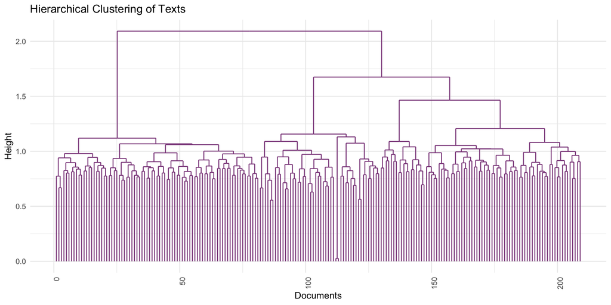

```r
# Convert the Jaccard distance matrix into a distance object
jaccard_dist <- as.dist(jaccard_matrix_ripper)

# Perform hierarchical clustering
hc <- hclust(jaccard_dist,
             method = "ward.D2")  # Ward's method for compact clusters

# Convert to dendrogram format for ggplot
hc_dendro <- as.dendrogram(hc)
hc_data <- dendro_data(hc_dendro)

# Plot with ggplot2
ggplot(segment(hc_data)) +
  geom_segment(aes(x = x,
                   y = y,
                   xend = xend,
                   yend = yend),
               color = "orchid4") +
  theme_minimal() +
  ggtitle("Hierarchical Clustering of Texts") +
  xlab("Documents") +
  ylab("Height") +
  theme(axis.text.x = element_text(angle = 90,
                                   hjust = 1))
```

## Jaccard in ‘idiolect’ library

We can also go back to the ‘idiolect’ library from last session. This also has the option to calculate Jaccard Distances and use them to show you the distance between texts. If we use the texts from last session, we can easily create a visualisation based on the Jaccard Coefficient.

If you wanted to apply this function to the Jack the Ripper text, you need to decide which of the texts are the known documents (maybe following Nini’s results) and which ones are questioned.

```r
# Read in the data
known_writing <- create_corpus(path_to_known)
questioned_writing <- create_corpus(path_to_disputed)

# Do the n-gram tracing and set coefficient to jaccard
ngrams <- ngram_tracing(questioned_writing,
                        known_writing,
                        coefficient = "jaccard")
```

Visualising n-gram traching

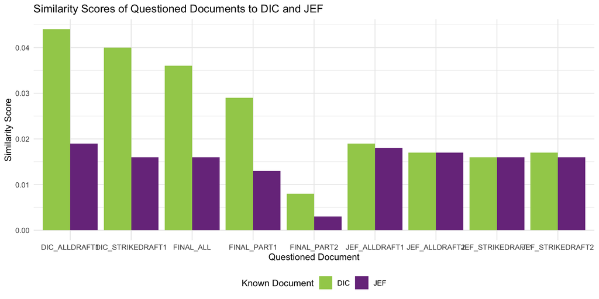

```r
# Create a bar plot to compare similarity scores
ggplot(ngrams,
       aes(x = Q,
           y = score,
           fill = K)
       ) +
  geom_bar(stat = "identity",
           position = "dodge") +  # Create side-by-side bars
  labs(title = "Similarity Scores of Questioned Documents to DIC and JEF",
       x = "Questioned Document",
       y = "Similarity Score",
       fill = "Known Document") +
  theme_minimal() +
  scale_fill_manual(values = c("darkolivegreen3",
                               "mediumorchid4")) +  # Set custom colors
  theme(legend.position = "bottom") +
  scale_x_discrete(labels = function(x) str_replace(x, ".txt", ""))  # Clean up x-axis labels
```